# Problem Statment

A Company wants to automate the loan eligibility process based on customer details provided while filling online application form. The details filled by the customer are Gender, Marital Status, Education, Number of Dependents, Income of self and co applicant, Required Loan Amount, Required Loan Term, Credit History and others. The requirements are as follows: 1.Check eligibility of the Customer given the inputs described above.(Classification) 2.Identify customer segments from given data and categorize customer into one of the segments.(Clustering) 3.)If customer is not eligible for the input required amount and duration: a.)what can be amount for the given duration.(Regression) b.)if duration is less than equal to 20 years, is customer eligible for required amount for some longer duration?(Regression) 1.Check eligibility of the Customer given the inputs described above.(Classification)

# Import Lib. and Filterwarnings

```python
import pandas as pd
import numpy as np
from warnings import filterwarnings
filterwarnings("ignore")
```

# Read Dataset

```python
train = pd.read_csv("C:/Users/hp/OneDrive/Desktop/DS/project2/training_set.csv")
test =pd.read_csv("C:/Users/hp/OneDrive/Desktop/DS/project2/testing_set.csv")
```

```python
train.head(3)
```

|  | Loan_ID | Gender | Married | Dependents | Education | Self_Employed | ApplicantIncome | CoapplicantIncome | LoanAmount | Loan_Amount_Term | Credit_History | Property_Area | Loan_Status |
| --- | --- | --- | --- | --- | --- | --- | --- | --- | --- | --- | --- | --- | --- |
| 0 | LP001002 | Male | No | 0 | Graduate | No | 5849.0 | 0.0 | NaN | 360.0 | 1.0 | Urban | Y |
| 1 | LP001003 | Male | Yes | 1 | Graduate | No | NaN | 1508.0 | 128.0 | 360.0 | 1.0 | Rural | N |
| 2 | LP001005 | Male | Yes | 0 | Graduate | Yes | 3000.0 | 0.0 | 66.0 | 360.0 | 1.0 | Urban | Y |

```python
train.columns
```

```
Index(['Loan_ID', 'Gender', 'Married', 'Dependents', 'Education',
       'Self_Employed', 'ApplicantIncome', 'CoapplicantIncome', 'LoanAmount',
       'Loan_Amount_Term', 'Credit_History', 'Property_Area', 'Loan_Status'],
      dtype='object')
```

```python
train.describe()
```

|  | ApplicantIncome | CoapplicantIncome | LoanAmount | Loan_Amount_Term | Credit_History |
| --- | --- | --- | --- | --- | --- |
| count | 612.000000 | 613.000000 | 592.000000 | 600.00000 | 564.000000 |
| mean | 5405.540850 | 1620.888940 | 146.412162 | 342.00000 | 0.842199 |
| std | 6118.914057 | 2928.624748 | 85.587325 | 65.12041 | 0.364878 |
| min | 150.000000 | 0.000000 | 9.000000 | 12.00000 | 0.000000 |
| 25% | 2875.750000 | 0.000000 | 100.000000 | 360.00000 | 1.000000 |
| 50% | 3806.000000 | 1167.000000 | 128.000000 | 360.00000 | 1.000000 |
| 75% | 5803.750000 | 2302.000000 | 168.000000 | 360.00000 | 1.000000 |
| max | 81000.000000 | 41667.000000 | 700.000000 | 480.00000 | 1.000000 |

```python
train.shape
```

```
(614, 13)
```

```python
test.head(3)
```

|  | Loan_ID | Gender | Married | Dependents | Education | Self_Employed | ApplicantIncome | CoapplicantIncome | LoanAmount | Loan_Amount_Term | Credit_History | Property_Area |
| --- | --- | --- | --- | --- | --- | --- | --- | --- | --- | --- | --- | --- |
| 0 | LP001015 | Male | Yes | 0 | Graduate | No | 5720 | 0 | 110.0 | 360.0 | 1.0 | Urban |
| 1 | LP001022 | Male | Yes | 1 | Graduate | No | 3076 | 1500 | 126.0 | 360.0 | 1.0 | Urban |
| 2 | LP001031 | Male | Yes | 2 | Graduate | No | 5000 | 1800 | 208.0 | 360.0 | 1.0 | Urban |

```python
test.describe()
```

|  | ApplicantIncome | CoapplicantIncome | LoanAmount | Loan_Amount_Term | Credit_History |
| --- | --- | --- | --- | --- | --- |
| count | 367.000000 | 367.000000 | 362.000000 | 361.000000 | 338.000000 |
| mean | 4805.599455 | 1569.577657 | 136.132597 | 342.537396 | 0.825444 |
| std | 4910.685399 | 2334.232099 | 61.366652 | 65.156643 | 0.380150 |
| min | 0.000000 | 0.000000 | 28.000000 | 6.000000 | 0.000000 |
| 25% | 2864.000000 | 0.000000 | 100.250000 | 360.000000 | 1.000000 |
| 50% | 3786.000000 | 1025.000000 | 125.000000 | 360.000000 | 1.000000 |
| 75% | 5060.000000 | 2430.500000 | 158.000000 | 360.000000 | 1.000000 |
| max | 72529.000000 | 24000.000000 | 550.000000 | 480.000000 | 1.000000 |

```python
test.columns
```

```
Index(['Loan_ID', 'Gender', 'Married', 'Dependents', 'Education',
       'Self_Employed', 'ApplicantIncome', 'CoapplicantIncome', 'LoanAmount',
       'Loan_Amount_Term', 'Credit_History', 'Property_Area'],
      dtype='object')
```

```python
test.shape
```

```
(367, 12)
```

# MISSING DATA TREATMENT

```python
train.isna().sum()
```

```
Loan_ID               0
Gender               15
Married               3
Dependents           15
Education             1
Self_Employed        32
ApplicantIncome       2
CoapplicantIncome     1
LoanAmount           22
Loan_Amount_Term     14
Credit_History       50
Property_Area         0
Loan_Status           0
dtype: int64
```

```python
from function import catconsep
catconsep(train)
```

```
(['Loan_ID',
  'Gender',
  'Married',
  'Dependents',
  'Education',
  'Self_Employed',
  'Property_Area',
  'Loan_Status'],
 ['ApplicantIncome',
  'CoapplicantIncome',
  'LoanAmount',
  'Loan_Amount_Term',
  'Credit_History'])
```

```python
from function import replacer
replacer(train)
train.isna().sum()
```

```
Loan_ID              0
Gender               0
Married              0
Dependents           0
Education            0
Self_Employed        0
ApplicantIncome      0
CoapplicantIncome    0
LoanAmount           0
Loan_Amount_Term     0
Credit_History       0
Property_Area        0
Loan_Status          0
dtype: int64
```

# Exploratory data analysis(EDA)

```python
pvals = []
from function import ANOVA,chisq
for i in train.columns:
    if(train[i].dtypes == "object"):
        pval = chisq(train,"Loan_Status",i)
        pvals.append(pval)
    else:
        pval = ANOVA(train,"Loan_Status",i)
        pvals.append(pval)

t3 = pd.DataFrame([train.columns,pvals]).T
t3.columns=["Col","Pval"]
t3.sort_values(by="Pval",ascending=False)
```

|  | Col | Pval |
| --- | --- | --- |
| 5 | Self_Employed | 1.0 |
| 6 | ApplicantIncome | 0.90247 |
| 1 | Gender | 0.72848 |
| 9 | Loan_Amount_Term | 0.60312 |
| 0 | Loan_ID | 0.48102 |
| 3 | Dependents | 0.36785 |
| 8 | LoanAmount | 0.36474 |
| 7 | CoapplicantIncome | 0.14257 |
| 4 | Education | 0.04465 |
| 2 | Married | 0.03439 |
| 11 | Property_Area | 0.00214 |
| 10 | Credit_History | 0.0 |
| 12 | Loan_Status | 0.0 |

```python
pvals
```

```
[0.48102,
 0.72848,
 0.03439,
 0.36785,
 0.04465,
 1.0,
 0.90247,
 0.14257,
 0.36474,
 0.60312,
 0.0,
 0.00214,
 0.0]
```

```python
from function import replacer
replacer(train)
replacer(test)
```

# Define X and Y

```python
Y = train[["Loan_Status"]]
X = train.drop(labels=["Loan_ID","Loan_Status"],axis=1)
```

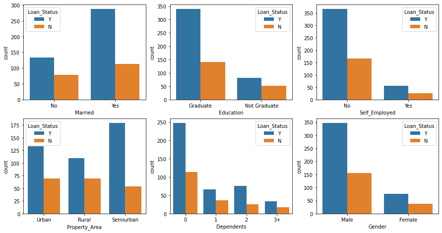

```python
import matplotlib.pyplot as plt
import seaborn as sb

plt.figure(figsize=(15,12))
plt.subplot(3,3,1)
sb.countplot(train.Married,hue=train.Loan_Status)
plt.subplot(3,3,2)
sb.countplot(train.Education,hue=train.Loan_Status)
plt.subplot(3,3,3)
sb.countplot(train.Self_Employed,hue=train.Loan_Status)
plt.subplot(3,3,4)
sb.countplot(train.Property_Area,hue=train.Loan_Status)
plt.subplot(3,3,5)
sb.countplot(train.Dependents,hue=train.Loan_Status)
plt.subplot(3,3,6)
sb.countplot(train.Gender,hue=train.Loan_Status)
```

# CatConSep

```python
from function import catconsep
cat,con = catconsep(X)
```

```python
cat
```

```
['Gender',
 'Married',
 'Dependents',
 'Education',
 'Self_Employed',
 'Property_Area']
```

```python
con
```

```
['ApplicantIncome',
 'CoapplicantIncome',
 'LoanAmount',
 'Loan_Amount_Term',
 'Credit_History']
```

# Preprocessing

```python
from function import preprocessing
Xnew= preprocessing(X)
```

```python
from sklearn.preprocessing import StandardScaler
ss = StandardScaler()
X1 = X[con]
X2 = pd.get_dummies(X[cat])
Xnew = X1.join(X2)
```

```python
Xtest = test.drop(labels=["Loan_ID"],axis=1)
cat_test,con_test = catconsep(Xtest)
Xtest_new =(Xtest)
from sklearn.preprocessing import StandardScaler
ss = StandardScaler()
X1_test = Xtest[con]
X2_test = pd.get_dummies(Xtest[cat])
Xtest_new = X1_test.join(X2)
```

```python
Xnew
```

|  | ApplicantIncome | CoapplicantIncome | LoanAmount | Loan_Amount_Term | Credit_History | Gender_Female | Gender_Male | Married_No | Married_Yes | Dependents_0 | Dependents_1 | Dependents_2 | Dependents_3+ | Education_Graduate | Education_Not Graduate | Self_Employed_No | Self_Employed_Yes | Property_Area_Rural | Property_Area_Semiurban | Property_Area_Urban |
| --- | --- | --- | --- | --- | --- | --- | --- | --- | --- | --- | --- | --- | --- | --- | --- | --- | --- | --- | --- | --- |
| 0 | 5849.00000 | 0.0 | 146.412162 | 360.0 | 1.0 | 0 | 1 | 1 | 0 | 1 | 0 | 0 | 0 | 1 | 0 | 1 | 0 | 0 | 0 | 1 |
| 1 | 5405.54085 | 1508.0 | 128.000000 | 360.0 | 1.0 | 0 | 1 | 0 | 1 | 0 | 1 | 0 | 0 | 1 | 0 | 1 | 0 | 1 | 0 | 0 |
| 2 | 3000.00000 | 0.0 | 66.000000 | 360.0 | 1.0 | 0 | 1 | 0 | 1 | 1 | 0 | 0 | 0 | 1 | 0 | 0 | 1 | 0 | 0 | 1 |
| 3 | 2583.00000 | 2358.0 | 120.000000 | 360.0 | 1.0 | 0 | 1 | 0 | 1 | 1 | 0 | 0 | 0 | 0 | 1 | 1 | 0 | 0 | 0 | 1 |
| 4 | 6000.00000 | 0.0 | 141.000000 | 360.0 | 1.0 | 0 | 1 | 1 | 0 | 1 | 0 | 0 | 0 | 1 | 0 | 1 | 0 | 0 | 0 | 1 |
| ... | ... | ... | ... | ... | ... | ... | ... | ... | ... | ... | ... | ... | ... | ... | ... | ... | ... | ... | ... | ... |
| 609 | 2900.00000 | 0.0 | 71.000000 | 360.0 | 1.0 | 1 | 0 | 1 | 0 | 1 | 0 | 0 | 0 | 1 | 0 | 1 | 0 | 1 | 0 | 0 |
| 610 | 4106.00000 | 0.0 | 40.000000 | 180.0 | 1.0 | 0 | 1 | 0 | 1 | 0 | 0 | 0 | 1 | 1 | 0 | 1 | 0 | 1 | 0 | 0 |
| 611 | 8072.00000 | 240.0 | 253.000000 | 360.0 | 1.0 | 0 | 1 | 0 | 1 | 0 | 1 | 0 | 0 | 1 | 0 | 1 | 0 | 0 | 0 | 1 |
| 612 | 7583.00000 | 0.0 | 187.000000 | 360.0 | 1.0 | 0 | 1 | 0 | 1 | 0 | 0 | 1 | 0 | 1 | 0 | 1 | 0 | 0 | 0 | 1 |
| 613 | 4583.00000 | 0.0 | 133.000000 | 360.0 | 0.0 | 1 | 0 | 1 | 0 | 1 | 0 | 0 | 0 | 1 | 0 | 0 | 1 | 0 | 1 | 0 |

614 rows × 20 columns

```python
Xtest
```

|  | Gender | Married | Dependents | Education | Self_Employed | ApplicantIncome | CoapplicantIncome | LoanAmount | Loan_Amount_Term | Credit_History | Property_Area |
| --- | --- | --- | --- | --- | --- | --- | --- | --- | --- | --- | --- |
| 0 | Male | Yes | 0 | Graduate | No | 5720 | 0 | 110.0 | 360.0 | 1.000000 | Urban |
| 1 | Male | Yes | 1 | Graduate | No | 3076 | 1500 | 126.0 | 360.0 | 1.000000 | Urban |
| 2 | Male | Yes | 2 | Graduate | No | 5000 | 1800 | 208.0 | 360.0 | 1.000000 | Urban |
| 3 | Male | Yes | 2 | Graduate | No | 2340 | 2546 | 100.0 | 360.0 | 0.825444 | Urban |
| 4 | Male | No | 0 | Not Graduate | No | 3276 | 0 | 78.0 | 360.0 | 1.000000 | Urban |
| ... | ... | ... | ... | ... | ... | ... | ... | ... | ... | ... | ... |
| 362 | Male | Yes | 3+ | Not Graduate | Yes | 4009 | 1777 | 113.0 | 360.0 | 1.000000 | Urban |
| 363 | Male | Yes | 0 | Graduate | No | 4158 | 709 | 115.0 | 360.0 | 1.000000 | Urban |
| 364 | Male | No | 0 | Graduate | No | 3250 | 1993 | 126.0 | 360.0 | 0.825444 | Semiurban |
| 365 | Male | Yes | 0 | Graduate | No | 5000 | 2393 | 158.0 | 360.0 | 1.000000 | Rural |
| 366 | Male | No | 0 | Graduate | Yes | 9200 | 0 | 98.0 | 180.0 | 1.000000 | Rural |

367 rows × 11 columns

# Train Test split

```python
from sklearn.model_selection import train_test_split
xtrain,xtest,ytrain,ytest=train_test_split(Xnew,Y,test_size=0.2,random_state=31)
```

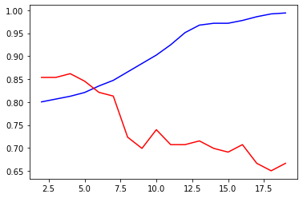

```python
tr = []
ts = []
from sklearn.tree import DecisionTreeClassifier
for i in range(2,20,1):

    dtc = DecisionTreeClassifier(criterion="entropy",random_state=21,max_depth=i)
    model = dtc.fit(xtrain,ytrain)
    pred_tr = model.predict(xtrain)
    pred_ts = model.predict(xtest)
    from sklearn.metrics import accuracy_score
    tr_acc = accuracy_score(ytrain,pred_tr)
    ts_acc = accuracy_score(ytest,pred_ts)
    tr.append(tr_acc)
    ts.append(ts_acc)

import matplotlib.pyplot as plt
plt.plot(range(2,20,1),tr,c="blue")
plt.plot(range(2,20,1),ts,c="red")
```

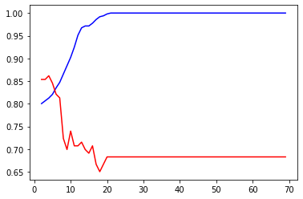

```python
tr = []
ts = []
from sklearn.tree import DecisionTreeClassifier
for i in range(2,70,1):

    dtc = DecisionTreeClassifier(criterion="entropy",random_state=21,max_depth=i)
    model = dtc.fit(xtrain,ytrain)
    pred_tr = model.predict(xtrain)
    pred_ts = model.predict(xtest)
    from sklearn.metrics import accuracy_score
    tr_acc = accuracy_score(ytrain,pred_tr)
    ts_acc = accuracy_score(ytest,pred_ts)
    tr.append(tr_acc)
    ts.append(ts_acc)

import matplotlib.pyplot as plt
plt.plot(range(2,70,1),tr,c="blue")
plt.plot(range(2,70,1),ts,c="red")
```

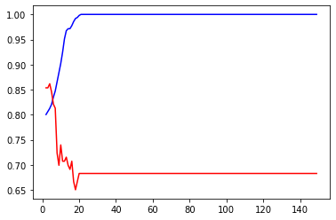

```python
tr = []
ts = []
from sklearn.tree import DecisionTreeClassifier
for i in range(2,150,1):

    dtc = DecisionTreeClassifier(criterion="entropy",random_state=21,max_depth=i)
    model = dtc.fit(xtrain,ytrain)
    pred_tr = model.predict(xtrain)
    pred_ts = model.predict(xtest)
    from sklearn.metrics import accuracy_score
    tr_acc = accuracy_score(ytrain,pred_tr)
    ts_acc = accuracy_score(ytest,pred_ts)
    tr.append(tr_acc)
    ts.append(ts_acc)

import matplotlib.pyplot as plt
plt.plot(range(2,150,1),tr,c="blue")
plt.plot(range(2,150,1),ts,c="red")
```

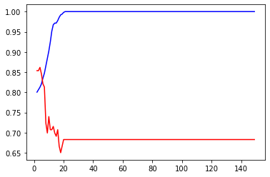

```python
tr = []
ts = []
from sklearn.tree import DecisionTreeClassifier
for i in range(2,150,1):

    dtc = DecisionTreeClassifier(criterion="entropy",random_state=21,max_depth=i)
    model = dtc.fit(xtrain,ytrain)
    pred_tr = model.predict(xtrain)
    pred_ts = model.predict(xtest)
    from sklearn.metrics import accuracy_score
    tr_acc = accuracy_score(ytrain,pred_tr)
    ts_acc = accuracy_score(ytest,pred_ts)
    tr.append(tr_acc)
    ts.append(ts_acc)

import matplotlib.pyplot as plt
plt.plot(range(2,150,1),tr,c="blue")
plt.plot(range(2,150,1),ts,c="red")
```

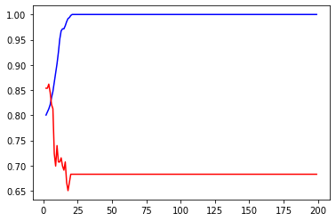

```python
tr = []
ts = []
from sklearn.tree import DecisionTreeClassifier
for i in range(2,200,1):

    dtc = DecisionTreeClassifier(criterion="entropy",random_state=21,max_depth=i)
    model = dtc.fit(xtrain,ytrain)
    pred_tr = model.predict(xtrain)
    pred_ts = model.predict(xtest)
    from sklearn.metrics import accuracy_score
    tr_acc = accuracy_score(ytrain,pred_tr)
    ts_acc = accuracy_score(ytest,pred_ts)
    tr.append(tr_acc)
    ts.append(ts_acc)

import matplotlib.pyplot as plt
plt.plot(range(2,200,1),tr,c="blue")
plt.plot(range(2,200,1),ts,c="red")
```

```python
from sklearn.tree import DecisionTreeClassifier
from sklearn.ensemble import AdaBoostClassifier

dtc = DecisionTreeClassifier(criterion="entropy",random_state=21,max_depth=4)

model_dtc = dtc.fit(xtrain,ytrain)
pred_tr = model_dtc.predict(xtrain)
pred_ts = model_dtc.predict(xtest)

from sklearn.metrics import accuracy_score
tr_acc = accuracy_score(ytrain,pred_tr)
ts_acc = accuracy_score(ytest,pred_ts)
```

```python
tr_acc
```

```
0.8126272912423625
```

```python
ts_acc
```

```
0.8617886178861789
```

```python
from sklearn.metrics import confusion_matrix
print(confusion_matrix(ytrain,pred_tr))
print(confusion_matrix(ytest,pred_ts))
```

```
[[ 72  86]
 [  6 327]]
[[17 17]
 [ 0 89]]
```

adaboost

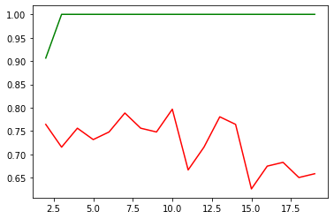

```python
tr = []
ts = []
for i in range(2,20,1):
    from sklearn.ensemble import RandomForestClassifier
    from sklearn.ensemble import AdaBoostClassifier
    dtc = DecisionTreeClassifier(criterion="entropy",random_state=21,max_depth=i)
    abc = AdaBoostClassifier(dtc,n_estimators=30)
    model = abc.fit(xtrain,ytrain)
    pred_tr = model.predict(xtrain)
    pred_ts = model.predict(xtest)
    from sklearn.metrics import accuracy_score
    tr_acc = accuracy_score(ytrain,pred_tr)
    ts_acc = accuracy_score(ytest,pred_ts)
    tr.append(tr_acc)
    ts.append(ts_acc)

import matplotlib.pyplot as plt
plt.plot(range(2,20,1),tr,c="green")
plt.plot(range(2,20,1),ts,c="red")
```

# Random Forest Classifier(RFC)

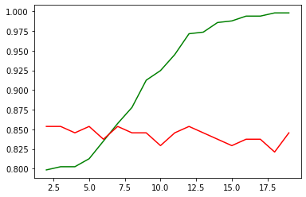

```python
tr = []
ts = []
for i in range(2,20,1):
    from sklearn.ensemble import RandomForestClassifier
    rfc = RandomForestClassifier(n_estimators=30,criterion="entropy",random_state=21,max_depth=i)
    model = rfc.fit(xtrain,ytrain)
    pred_tr = model.predict(xtrain)
    pred_ts = model.predict(xtest)
    from sklearn.metrics import accuracy_score
    tr_acc = accuracy_score(ytrain,pred_tr)
    ts_acc = accuracy_score(ytest,pred_ts)
    tr.append(tr_acc)
    ts.append(ts_acc)


import matplotlib.pyplot as plt
plt.plot(range(2,20,1),tr,c="green")
plt.plot(range(2,20,1),ts,c="red")
```

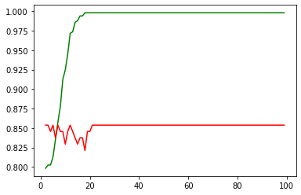

```python
tr = []
ts = []
for i in range(2,100,1):
    from sklearn.ensemble import RandomForestClassifier
    rfc = RandomForestClassifier(n_estimators=30,criterion="entropy",random_state=21,max_depth=i)
    model = rfc.fit(xtrain,ytrain)
    pred_tr = model.predict(xtrain)
    pred_ts = model.predict(xtest)
    from sklearn.metrics import accuracy_score
    tr_acc = accuracy_score(ytrain,pred_tr)
    ts_acc = accuracy_score(ytest,pred_ts)
    tr.append(tr_acc)
    ts.append(ts_acc)


import matplotlib.pyplot as plt
plt.plot(range(2,100,1),tr,c="green")
plt.plot(range(2,100,1),ts,c="red")
```

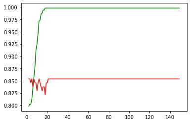

```python
tr = []
ts = []
for i in range(2,150,1):
    from sklearn.ensemble import RandomForestClassifier
    rfc = RandomForestClassifier(n_estimators=30,criterion="entropy",random_state=21,max_depth=i)
    model = rfc.fit(xtrain,ytrain)
    pred_tr = model.predict(xtrain)
    pred_ts = model.predict(xtest)
    from sklearn.metrics import accuracy_score
    tr_acc = accuracy_score(ytrain,pred_tr)
    ts_acc = accuracy_score(ytest,pred_ts)
    tr.append(tr_acc)
    ts.append(ts_acc)


import matplotlib.pyplot as plt
plt.plot(range(2,150,1),tr,c="green")
plt.plot(range(2,150,1),ts,c="red")
```

```python
from sklearn.ensemble import RandomForestClassifier
rfc = RandomForestClassifier(n_estimators=30,criterion="entropy",random_state=21,max_depth=5)
model = rfc.fit(xtrain,ytrain)
pred_tr = model.predict(xtrain)
pred_ts = model.predict(xtest)

from sklearn.metrics import accuracy_score
tr_acc = accuracy_score(ytrain,pred_tr)
ts_acc = accuracy_score(ytest,pred_ts)
```

```python
tr_acc
```

```
0.8126272912423625
```

```python
ts_acc
```

```
0.8536585365853658
```

```python
from sklearn.metrics import confusion_matrix
print(confusion_matrix(ytrain,pred_tr))
print(confusion_matrix(ytest,pred_ts))
```

```
[[ 71  87]
 [  5 328]]
[[16 18]
 [ 0 89]]
```

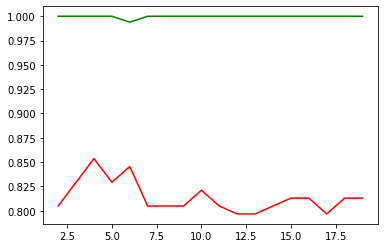

```python
tr = []
ts = []
for i in range(2,20,1):
    from sklearn.ensemble import RandomForestClassifier
    rfc = RandomForestClassifier(n_estimators=30,criterion="entropy",random_state=21,min_samples_split=i)
    abc = AdaBoostClassifier(rfc,n_estimators=30)
    model = abc.fit(xtrain,ytrain)
    pred_tr = model.predict(xtrain)
    pred_ts = model.predict(xtest)
    from sklearn.metrics import accuracy_score
    tr_acc = accuracy_score(ytrain,pred_tr)
    ts_acc = accuracy_score(ytest,pred_ts)
    tr.append(tr_acc)
    ts.append(ts_acc)


import matplotlib.pyplot as plt
plt.plot(range(2,20,1),tr,c="green")
plt.plot(range(2,20,1),ts,c="red")
```

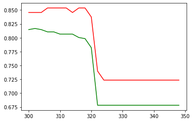

```python
tr = []
ts = []
for i in range(300,350,2):
    from sklearn.ensemble import RandomForestClassifier
    rfc = RandomForestClassifier(n_estimators=30,criterion="entropy",random_state=21,min_samples_split=i)
    abc = AdaBoostClassifier(rfc,n_estimators=30)
    model = abc.fit(xtrain,ytrain)
    pred_tr = model.predict(xtrain)
    pred_ts = model.predict(xtest)
    from sklearn.metrics import accuracy_score
    tr_acc = accuracy_score(ytrain,pred_tr)
    ts_acc = accuracy_score(ytest,pred_ts)
    tr.append(tr_acc)
    ts.append(ts_acc)


import matplotlib.pyplot as plt
plt.plot(range(300,350,2),tr,c="green")
plt.plot(range(300,350,2),ts,c="red")
```

# Logistic Regression(LR)

```python
from sklearn.model_selection import train_test_split
xtrain,xtest,ytrain,ytest=train_test_split(Xnew,Y,test_size=0.2,random_state=41)
```

```python
from sklearn.linear_model import LogisticRegression
lr = LogisticRegression()
model = lr.fit(xtrain,ytrain)
pred_tr = model.predict(xtrain)
pred_ts = model.predict(xtest)

from sklearn.metrics import accuracy_score
print(round(accuracy_score(ytrain,pred_tr),2))
print(round(accuracy_score(ytest,pred_ts),2))
```

```
0.81
0.8
```

```python
from sklearn.metrics import confusion_matrix
print(confusion_matrix(ytrain,pred_tr))
print(confusion_matrix(ytest,pred_ts))
```

```
[[ 67  84]
 [  8 332]]
[[19 22]
 [ 2 80]]
```

# Decision tree last model

```python
from sklearn.model_selection import train_test_split
xtrain,xtest,ytrain,ytest=train_test_split(Xnew,Y,test_size=0.2,random_state=21)

from sklearn.tree import DecisionTreeClassifier

dtc = DecisionTreeClassifier(criterion="entropy",random_state=21,max_depth=5)

model_dtc = dtc.fit(xtrain,ytrain)
pred_tr = model_dtc.predict(xtrain)
pred_ts = model_dtc.predict(xtest)

from sklearn.metrics import accuracy_score
tr_acc = accuracy_score(ytrain,pred_tr)
ts_acc = accuracy_score(ytest,pred_ts)

print(round(tr_acc,4))
print(round(ts_acc,4))
```

```
0.8269
0.8211
```

# Testing Set

```python
Xtest_new
```

|  | ApplicantIncome | CoapplicantIncome | LoanAmount | Loan_Amount_Term | Credit_History | Gender_Female | Gender_Male | Married_No | Married_Yes | Dependents_0 | Dependents_1 | Dependents_2 | Dependents_3+ | Education_Graduate | Education_Not Graduate | Self_Employed_No | Self_Employed_Yes | Property_Area_Rural | Property_Area_Semiurban | Property_Area_Urban |
| --- | --- | --- | --- | --- | --- | --- | --- | --- | --- | --- | --- | --- | --- | --- | --- | --- | --- | --- | --- | --- |
| 0 | 5720 | 0 | 110.0 | 360.0 | 1.000000 | 0 | 1 | 1 | 0 | 1 | 0 | 0 | 0 | 1 | 0 | 1 | 0 | 0 | 0 | 1 |
| 1 | 3076 | 1500 | 126.0 | 360.0 | 1.000000 | 0 | 1 | 0 | 1 | 0 | 1 | 0 | 0 | 1 | 0 | 1 | 0 | 1 | 0 | 0 |
| 2 | 5000 | 1800 | 208.0 | 360.0 | 1.000000 | 0 | 1 | 0 | 1 | 1 | 0 | 0 | 0 | 1 | 0 | 0 | 1 | 0 | 0 | 1 |
| 3 | 2340 | 2546 | 100.0 | 360.0 | 0.825444 | 0 | 1 | 0 | 1 | 1 | 0 | 0 | 0 | 0 | 1 | 1 | 0 | 0 | 0 | 1 |
| 4 | 3276 | 0 | 78.0 | 360.0 | 1.000000 | 0 | 1 | 1 | 0 | 1 | 0 | 0 | 0 | 1 | 0 | 1 | 0 | 0 | 0 | 1 |
| ... | ... | ... | ... | ... | ... | ... | ... | ... | ... | ... | ... | ... | ... | ... | ... | ... | ... | ... | ... | ... |
| 362 | 4009 | 1777 | 113.0 | 360.0 | 1.000000 | 0 | 1 | 0 | 1 | 1 | 0 | 0 | 0 | 1 | 0 | 1 | 0 | 0 | 0 | 1 |
| 363 | 4158 | 709 | 115.0 | 360.0 | 1.000000 | 0 | 1 | 0 | 1 | 1 | 0 | 0 | 0 | 1 | 0 | 1 | 0 | 0 | 0 | 1 |
| 364 | 3250 | 1993 | 126.0 | 360.0 | 0.825444 | 0 | 1 | 1 | 0 | 1 | 0 | 0 | 0 | 1 | 0 | 0 | 1 | 1 | 0 | 0 |
| 365 | 5000 | 2393 | 158.0 | 360.0 | 1.000000 | 0 | 1 | 1 | 0 | 1 | 0 | 0 | 0 | 0 | 1 | 1 | 0 | 1 | 0 | 0 |
| 366 | 9200 | 0 | 98.0 | 180.0 | 1.000000 | 0 | 1 | 1 | 0 | 1 | 0 | 0 | 0 | 1 | 0 | 1 | 0 | 0 | 1 | 0 |

367 rows × 20 columns

```python
pred_testset = model_dtc.predict(Xtest_new)
```

```python
pred_testset
```

```
array(['Y', 'Y', 'Y', 'Y', 'Y', 'Y', 'Y', 'N', 'Y', 'Y', 'Y', 'Y', 'Y',
       'N', 'Y', 'Y', 'Y', 'Y', 'Y', 'Y', 'Y', 'Y', 'Y', 'Y', 'Y', 'N',
       'Y', 'Y', 'Y', 'Y', 'Y', 'Y', 'Y', 'Y', 'Y', 'N', 'Y', 'Y', 'Y',
       'Y', 'Y', 'Y', 'Y', 'Y', 'Y', 'Y', 'Y', 'Y', 'Y', 'Y', 'Y', 'Y',
       'Y', 'Y', 'Y', 'N', 'Y', 'Y', 'N', 'Y', 'Y', 'Y', 'Y', 'N', 'Y',
       'Y', 'N', 'N', 'Y', 'N', 'Y', 'Y', 'N', 'Y', 'Y', 'Y', 'Y', 'Y',
       'Y', 'Y', 'N', 'Y', 'N', 'Y', 'N', 'N', 'Y', 'Y', 'Y', 'Y', 'Y',
       'Y', 'Y', 'Y', 'N', 'Y', 'Y', 'Y', 'Y', 'N', 'Y', 'N', 'Y', 'Y',
       'Y', 'Y', 'N', 'Y', 'Y', 'Y', 'Y', 'Y', 'Y', 'Y', 'Y', 'Y', 'Y',
       'N', 'N', 'N', 'Y', 'Y', 'Y', 'N', 'N', 'Y', 'N', 'Y', 'Y', 'Y',
       'Y', 'Y', 'Y', 'Y', 'Y', 'Y', 'Y', 'Y', 'Y', 'Y', 'N', 'Y', 'Y',
       'N', 'Y', 'Y', 'Y', 'N', 'Y', 'Y', 'Y', 'Y', 'Y', 'N', 'Y', 'Y',
       'Y', 'Y', 'Y', 'Y', 'Y', 'N', 'Y', 'Y', 'Y', 'N', 'N', 'Y', 'N',
       'Y', 'Y', 'Y', 'Y', 'N', 'N', 'Y', 'Y', 'Y', 'Y', 'Y', 'Y', 'Y',
       'Y', 'Y', 'Y', 'Y', 'Y', 'Y', 'Y', 'Y', 'Y', 'Y', 'N', 'N', 'Y',
       'Y', 'N', 'Y', 'N', 'Y', 'Y', 'Y', 'Y', 'Y', 'Y', 'Y', 'Y', 'Y',
       'Y', 'Y', 'Y', 'N', 'Y', 'Y', 'Y', 'Y', 'Y', 'Y', 'Y', 'Y', 'Y',
       'Y', 'Y', 'Y', 'N', 'Y', 'Y', 'Y', 'Y', 'N', 'N', 'Y', 'Y', 'Y',
       'Y', 'N', 'N', 'Y', 'Y', 'Y', 'Y', 'N', 'Y', 'N', 'Y', 'N', 'Y',
       'Y', 'Y', 'Y', 'N', 'Y', 'Y', 'Y', 'Y', 'N', 'Y', 'Y', 'Y', 'Y',
       'Y', 'Y', 'Y', 'Y', 'Y', 'Y', 'N', 'Y', 'N', 'Y', 'Y', 'Y', 'Y',
       'N', 'N', 'Y', 'Y', 'Y', 'N', 'Y', 'Y', 'Y', 'Y', 'Y', 'Y', 'Y',
       'Y', 'Y', 'Y', 'Y', 'Y', 'Y', 'Y', 'N', 'Y', 'Y', 'Y', 'Y', 'Y',
       'Y', 'Y', 'N', 'Y', 'Y', 'Y', 'Y', 'Y', 'Y', 'Y', 'Y', 'Y', 'N',
       'Y', 'Y', 'Y', 'Y', 'Y', 'N', 'Y', 'Y', 'Y', 'Y', 'Y', 'Y', 'Y',
       'N', 'Y', 'Y', 'Y', 'Y', 'Y', 'Y', 'Y', 'Y', 'Y', 'Y', 'Y', 'Y',
       'Y', 'N', 'Y', 'Y', 'Y', 'Y', 'Y', 'Y', 'N', 'Y', 'Y', 'Y', 'Y',
       'N', 'Y', 'Y', 'N', 'Y', 'Y', 'Y', 'Y', 'Y', 'Y', 'Y', 'Y', 'Y',
       'Y', 'Y', 'Y'], dtype=object)
```

```python
test
```

|  | Loan_ID | Gender | Married | Dependents | Education | Self_Employed | ApplicantIncome | CoapplicantIncome | LoanAmount | Loan_Amount_Term | Credit_History | Property_Area |
| --- | --- | --- | --- | --- | --- | --- | --- | --- | --- | --- | --- | --- |
| 0 | LP001015 | Male | Yes | 0 | Graduate | No | 5720 | 0 | 110.0 | 360.0 | 1.000000 | Urban |
| 1 | LP001022 | Male | Yes | 1 | Graduate | No | 3076 | 1500 | 126.0 | 360.0 | 1.000000 | Urban |
| 2 | LP001031 | Male | Yes | 2 | Graduate | No | 5000 | 1800 | 208.0 | 360.0 | 1.000000 | Urban |
| 3 | LP001035 | Male | Yes | 2 | Graduate | No | 2340 | 2546 | 100.0 | 360.0 | 0.825444 | Urban |
| 4 | LP001051 | Male | No | 0 | Not Graduate | No | 3276 | 0 | 78.0 | 360.0 | 1.000000 | Urban |
| ... | ... | ... | ... | ... | ... | ... | ... | ... | ... | ... | ... | ... |
| 362 | LP002971 | Male | Yes | 3+ | Not Graduate | Yes | 4009 | 1777 | 113.0 | 360.0 | 1.000000 | Urban |
| 363 | LP002975 | Male | Yes | 0 | Graduate | No | 4158 | 709 | 115.0 | 360.0 | 1.000000 | Urban |
| 364 | LP002980 | Male | No | 0 | Graduate | No | 3250 | 1993 | 126.0 | 360.0 | 0.825444 | Semiurban |
| 365 | LP002986 | Male | Yes | 0 | Graduate | No | 5000 | 2393 | 158.0 | 360.0 | 1.000000 | Rural |
| 366 | LP002989 | Male | No | 0 | Graduate | Yes | 9200 | 0 | 98.0 | 180.0 | 1.000000 | Rural |

367 rows × 12 columns

```python
R = test[["Loan_ID"]]
R["Loan_Status"]=pred_testset
```

```python
R
```

|  | Loan_ID | Loan_Status |
| --- | --- | --- |
| 0 | LP001015 | Y |
| 1 | LP001022 | Y |
| 2 | LP001031 | Y |
| 3 | LP001035 | Y |
| 4 | LP001051 | Y |
| ... | ... | ... |
| 362 | LP002971 | Y |
| 363 | LP002975 | Y |
| 364 | LP002980 | Y |
| 365 | LP002986 | Y |
| 366 | LP002989 | Y |

367 rows × 2 columns

Problems statement -2 Identify customer segments from given data and categorize customer into one of the segments.(Clustering)

```python
train
```

|  | Loan_ID | Gender | Married | Dependents | Education | Self_Employed | ApplicantIncome | CoapplicantIncome | LoanAmount | Loan_Amount_Term | Credit_History | Property_Area | Loan_Status |
| --- | --- | --- | --- | --- | --- | --- | --- | --- | --- | --- | --- | --- | --- |
| 0 | LP001002 | Male | No | 0 | Graduate | No | 5849.00000 | 0.0 | 146.412162 | 360.0 | 1.0 | Urban | Y |
| 1 | LP001003 | Male | Yes | 1 | Graduate | No | 5405.54085 | 1508.0 | 128.000000 | 360.0 | 1.0 | Rural | N |
| 2 | LP001005 | Male | Yes | 0 | Graduate | Yes | 3000.00000 | 0.0 | 66.000000 | 360.0 | 1.0 | Urban | Y |
| 3 | LP001006 | Male | Yes | 0 | Not Graduate | No | 2583.00000 | 2358.0 | 120.000000 | 360.0 | 1.0 | Urban | Y |
| 4 | LP001008 | Male | No | 0 | Graduate | No | 6000.00000 | 0.0 | 141.000000 | 360.0 | 1.0 | Urban | Y |
| ... | ... | ... | ... | ... | ... | ... | ... | ... | ... | ... | ... | ... | ... |
| 609 | LP002978 | Female | No | 0 | Graduate | No | 2900.00000 | 0.0 | 71.000000 | 360.0 | 1.0 | Rural | Y |
| 610 | LP002979 | Male | Yes | 3+ | Graduate | No | 4106.00000 | 0.0 | 40.000000 | 180.0 | 1.0 | Rural | Y |
| 611 | LP002983 | Male | Yes | 1 | Graduate | No | 8072.00000 | 240.0 | 253.000000 | 360.0 | 1.0 | Urban | Y |
| 612 | LP002984 | Male | Yes | 2 | Graduate | No | 7583.00000 | 0.0 | 187.000000 | 360.0 | 1.0 | Urban | Y |
| 613 | LP002990 | Female | No | 0 | Graduate | Yes | 4583.00000 | 0.0 | 133.000000 | 360.0 | 0.0 | Semiurban | N |

614 rows × 13 columns

```python
A= train[["Property_Area"]]
```

```python
A
```

|  | Property_Area |
| --- | --- |
| 0 | Urban |
| 1 | Rural |
| 2 | Urban |
| 3 | Urban |
| 4 | Urban |
| ... | ... |
| 609 | Rural |
| 610 | Rural |
| 611 | Urban |
| 612 | Urban |
| 613 | Semiurban |

614 rows × 1 columns

```python
bnew=pd.get_dummies(A)
```

```python
bnew
```

|  | Property_Area_Rural | Property_Area_Semiurban | Property_Area_Urban |
| --- | --- | --- | --- |
| 0 | 0 | 0 | 1 |
| 1 | 1 | 0 | 0 |
| 2 | 0 | 0 | 1 |
| 3 | 0 | 0 | 1 |
| 4 | 0 | 0 | 1 |
| ... | ... | ... | ... |
| 609 | 1 | 0 | 0 |
| 610 | 1 | 0 | 0 |
| 611 | 0 | 0 | 1 |
| 612 | 0 | 0 | 1 |
| 613 | 0 | 1 | 0 |

614 rows × 3 columns

# Clustering

```python
from sklearn.cluster import KMeans
pm= KMeans(n_clusters=3)
model = pm.fit(bnew)
```

```python
model.labels_
```

```
array([0, 2, 0, 0, 0, 0, 0, 1, 0, 1, 0, 0, 0, 2, 0, 0, 0, 0, 2, 0, 0, 0,
       1, 2, 1, 1, 1, 0, 0, 1, 0, 0, 2, 1, 2, 0, 0, 1, 0, 1, 0, 0, 0, 1,
       0, 0, 0, 0, 0, 1, 1, 1, 1, 0, 0, 1, 1, 2, 0, 0, 0, 0, 2, 2, 1, 1,
       0, 0, 0, 1, 0, 1, 1, 1, 1, 0, 0, 0, 1, 1, 1, 1, 0, 1, 0, 1, 1, 1,
       0, 1, 1, 1, 0, 1, 1, 0, 1, 1, 1, 1, 0, 1, 0, 1, 0, 0, 0, 2, 0, 1,
       0, 1, 2, 1, 1, 2, 1, 0, 2, 0, 2, 1, 1, 1, 2, 2, 2, 2, 0, 2, 0, 0,
       1, 1, 1, 1, 2, 0, 1, 2, 2, 0, 1, 1, 0, 1, 0, 0, 2, 1, 2, 2, 0, 2,
       0, 1, 2, 0, 2, 1, 1, 0, 1, 2, 0, 2, 2, 2, 1, 1, 2, 0, 2, 1, 1, 2,
       2, 1, 1, 0, 0, 2, 1, 1, 1, 1, 2, 2, 2, 2, 2, 1, 0, 1, 2, 1, 2, 0,
       1, 0, 1, 1, 0, 0, 1, 1, 0, 2, 0, 1, 1, 1, 0, 2, 0, 1, 2, 1, 1, 1,
       0, 1, 1, 1, 1, 2, 0, 1, 1, 2, 1, 2, 2, 1, 1, 2, 0, 0, 2, 1, 2, 0,
       0, 2, 1, 0, 0, 0, 1, 0, 1, 0, 2, 1, 0, 2, 2, 0, 2, 1, 0, 1, 1, 2,
       1, 2, 1, 0, 2, 0, 0, 0, 2, 1, 1, 1, 1, 0, 1, 2, 0, 1, 0, 0, 2, 2,
       1, 2, 1, 2, 2, 1, 0, 0, 1, 0, 1, 0, 2, 0, 0, 1, 2, 0, 2, 0, 2, 0,
       2, 2, 1, 1, 2, 2, 2, 0, 1, 0, 1, 2, 1, 1, 2, 2, 2, 2, 2, 1, 0, 0,
       0, 1, 0, 0, 0, 1, 2, 2, 0, 1, 2, 2, 0, 1, 2, 1, 2, 0, 1, 2, 1, 2,
       2, 2, 1, 0, 2, 0, 0, 1, 1, 1, 0, 0, 2, 2, 1, 2, 1, 2, 1, 1, 2, 0,
       0, 0, 2, 1, 0, 0, 1, 1, 0, 0, 0, 0, 1, 0, 0, 2, 2, 2, 0, 1, 0, 1,
       0, 0, 2, 1, 0, 2, 1, 1, 2, 1, 0, 2, 1, 2, 1, 0, 2, 2, 1, 0, 0, 0,
       2, 1, 2, 0, 0, 0, 1, 2, 2, 1, 2, 0, 1, 2, 1, 1, 0, 1, 1, 0, 0, 2,
       1, 2, 1, 1, 2, 2, 2, 2, 2, 1, 2, 0, 2, 2, 1, 1, 0, 0, 2, 1, 1, 0,
       2, 1, 1, 2, 0, 1, 1, 0, 1, 2, 1, 0, 2, 2, 1, 1, 1, 0, 2, 2, 1, 1,
       1, 2, 2, 0, 1, 0, 1, 0, 2, 1, 2, 1, 2, 0, 1, 2, 2, 1, 1, 2, 1, 2,
       0, 0, 0, 0, 2, 1, 0, 1, 2, 2, 1, 1, 1, 2, 1, 1, 2, 2, 1, 2, 1, 1,
       1, 1, 2, 0, 2, 1, 0, 2, 0, 1, 2, 2, 1, 1, 1, 0, 1, 2, 1, 2, 1, 2,
       2, 2, 0, 0, 2, 1, 0, 1, 1, 1, 1, 1, 2, 1, 0, 2, 0, 2, 0, 0, 0, 0,
       0, 1, 1, 0, 1, 0, 2, 0, 1, 0, 1, 2, 2, 2, 0, 1, 1, 1, 1, 1, 1, 2,
       0, 2, 2, 1, 2, 0, 0, 2, 0, 2, 1, 0, 1, 2, 2, 2, 2, 0, 0, 1])
```

```python
bnew['Cluster_no']=model.labels_
```

```python
bnew["Property_Area"]=train.Property_Area
bnew['LoanAmount']=train.LoanAmount
```

```python
bnew.sort_values(by="Cluster_no")
```

|  | Property_Area_Rural | Property_Area_Semiurban | Property_Area_Urban | Cluster_no | Property_Area | LoanAmount |
| --- | --- | --- | --- | --- | --- | --- |
| 0 | 0 | 0 | 1 | 0 | Urban | 146.412162 |
| 451 | 0 | 0 | 1 | 0 | Urban | 60.000000 |
| 438 | 0 | 0 | 1 | 0 | Urban | 187.000000 |
| 437 | 0 | 0 | 1 | 0 | Urban | 146.412162 |
| 434 | 0 | 0 | 1 | 0 | Urban | 100.000000 |
| ... | ... | ... | ... | ... | ... | ... |
| 447 | 1 | 0 | 0 | 2 | Rural | 55.000000 |
| 448 | 1 | 0 | 0 | 2 | Rural | 150.000000 |
| 450 | 1 | 0 | 0 | 2 | Rural | 125.000000 |
| 190 | 1 | 0 | 0 | 2 | Rural | 48.000000 |
| 306 | 1 | 0 | 0 | 2 | Rural | 135.000000 |

614 rows × 6 columns

```python
k = input("Enter the Property_Area:")
cluster_no_of_input = bnew[bnew.Property_Area==k].Cluster_no.values[0]
max_loan=bnew[(bnew['Cluster_no'] == cluster_no_of_input)].LoanAmount.max()
min_loan=bnew[(bnew['Cluster_no'] == cluster_no_of_input)].LoanAmount.min()
```

```
Enter the Property_Area:Urban
```

```python
max_loan
```

```
700.0
```

```python
min_loan
```

```
9.0
```

```python
k = input("Enter the Property_Area:")
cluster_no_of_input = bnew[bnew.Property_Area==k].Cluster_no.values[0]
max_loan=bnew[(bnew['Cluster_no'] == cluster_no_of_input)].LoanAmount.max()
min_loan=bnew[(bnew['Cluster_no'] == cluster_no_of_input)].LoanAmount.min()
```

```
Enter the Property_Area:Rural
```

```python
max_loan
```

```
570.0
```

```python
min_loan
```

```
40.0
```

```python
k = input("Enter the Property_Area:")
cluster_no_of_input = bnew[bnew.Property_Area==k].Cluster_no.values[0]
max_loan=bnew[(bnew['Cluster_no'] == cluster_no_of_input)].LoanAmount.max()
min_loan=bnew[(bnew['Cluster_no'] == cluster_no_of_input)].LoanAmount.min()
```

```
Enter the Property_Area:Semiurban
```

```python
max_loan
```

```
600.0
```

```python
min_loan
```

```
25.0
```

```python
train
```

|  | Loan_ID | Gender | Married | Dependents | Education | Self_Employed | ApplicantIncome | CoapplicantIncome | LoanAmount | Loan_Amount_Term | Credit_History | Property_Area | Loan_Status |
| --- | --- | --- | --- | --- | --- | --- | --- | --- | --- | --- | --- | --- | --- |
| 0 | LP001002 | Male | No | 0 | Graduate | No | 5849.00000 | 0.0 | 146.412162 | 360.0 | 1.0 | Urban | Y |
| 1 | LP001003 | Male | Yes | 1 | Graduate | No | 5405.54085 | 1508.0 | 128.000000 | 360.0 | 1.0 | Rural | N |
| 2 | LP001005 | Male | Yes | 0 | Graduate | Yes | 3000.00000 | 0.0 | 66.000000 | 360.0 | 1.0 | Urban | Y |
| 3 | LP001006 | Male | Yes | 0 | Not Graduate | No | 2583.00000 | 2358.0 | 120.000000 | 360.0 | 1.0 | Urban | Y |
| 4 | LP001008 | Male | No | 0 | Graduate | No | 6000.00000 | 0.0 | 141.000000 | 360.0 | 1.0 | Urban | Y |
| ... | ... | ... | ... | ... | ... | ... | ... | ... | ... | ... | ... | ... | ... |
| 609 | LP002978 | Female | No | 0 | Graduate | No | 2900.00000 | 0.0 | 71.000000 | 360.0 | 1.0 | Rural | Y |
| 610 | LP002979 | Male | Yes | 3+ | Graduate | No | 4106.00000 | 0.0 | 40.000000 | 180.0 | 1.0 | Rural | Y |
| 611 | LP002983 | Male | Yes | 1 | Graduate | No | 8072.00000 | 240.0 | 253.000000 | 360.0 | 1.0 | Urban | Y |
| 612 | LP002984 | Male | Yes | 2 | Graduate | No | 7583.00000 | 0.0 | 187.000000 | 360.0 | 1.0 | Urban | Y |
| 613 | LP002990 | Female | No | 0 | Graduate | Yes | 4583.00000 | 0.0 | 133.000000 | 360.0 | 0.0 | Semiurban | N |

614 rows × 13 columns

```python
R=pred=model.predict
```

```python
tr=["Loan_ID"]
ts=["Loan_Amount"]
```

```python
tr
```

```
['Loan_ID']
```

```python
ts
```

```
['Loan_Amount']
```

```python
X1
```

|  | ApplicantIncome | CoapplicantIncome | LoanAmount | Loan_Amount_Term | Credit_History |
| --- | --- | --- | --- | --- | --- |
| 0 | 5849.00000 | 0.0 | 146.412162 | 360.0 | 1.0 |
| 1 | 5405.54085 | 1508.0 | 128.000000 | 360.0 | 1.0 |
| 2 | 3000.00000 | 0.0 | 66.000000 | 360.0 | 1.0 |
| 3 | 2583.00000 | 2358.0 | 120.000000 | 360.0 | 1.0 |
| 4 | 6000.00000 | 0.0 | 141.000000 | 360.0 | 1.0 |
| ... | ... | ... | ... | ... | ... |
| 609 | 2900.00000 | 0.0 | 71.000000 | 360.0 | 1.0 |
| 610 | 4106.00000 | 0.0 | 40.000000 | 180.0 | 1.0 |
| 611 | 8072.00000 | 240.0 | 253.000000 | 360.0 | 1.0 |
| 612 | 7583.00000 | 0.0 | 187.000000 | 360.0 | 1.0 |
| 613 | 4583.00000 | 0.0 | 133.000000 | 360.0 | 0.0 |

614 rows × 5 columns

```python
X2
```

|  | Gender_Female | Gender_Male | Married_No | Married_Yes | Dependents_0 | Dependents_1 | Dependents_2 | Dependents_3+ | Education_Graduate | Education_Not Graduate | Self_Employed_No | Self_Employed_Yes | Property_Area_Rural | Property_Area_Semiurban | Property_Area_Urban |
| --- | --- | --- | --- | --- | --- | --- | --- | --- | --- | --- | --- | --- | --- | --- | --- |
| 0 | 0 | 1 | 1 | 0 | 1 | 0 | 0 | 0 | 1 | 0 | 1 | 0 | 0 | 0 | 1 |
| 1 | 0 | 1 | 0 | 1 | 0 | 1 | 0 | 0 | 1 | 0 | 1 | 0 | 1 | 0 | 0 |
| 2 | 0 | 1 | 0 | 1 | 1 | 0 | 0 | 0 | 1 | 0 | 0 | 1 | 0 | 0 | 1 |
| 3 | 0 | 1 | 0 | 1 | 1 | 0 | 0 | 0 | 0 | 1 | 1 | 0 | 0 | 0 | 1 |
| 4 | 0 | 1 | 1 | 0 | 1 | 0 | 0 | 0 | 1 | 0 | 1 | 0 | 0 | 0 | 1 |
| ... | ... | ... | ... | ... | ... | ... | ... | ... | ... | ... | ... | ... | ... | ... | ... |
| 609 | 1 | 0 | 1 | 0 | 1 | 0 | 0 | 0 | 1 | 0 | 1 | 0 | 1 | 0 | 0 |
| 610 | 0 | 1 | 0 | 1 | 0 | 0 | 0 | 1 | 1 | 0 | 1 | 0 | 1 | 0 | 0 |
| 611 | 0 | 1 | 0 | 1 | 0 | 1 | 0 | 0 | 1 | 0 | 1 | 0 | 0 | 0 | 1 |
| 612 | 0 | 1 | 0 | 1 | 0 | 0 | 1 | 0 | 1 | 0 | 1 | 0 | 0 | 0 | 1 |
| 613 | 1 | 0 | 1 | 0 | 1 | 0 | 0 | 0 | 1 | 0 | 0 | 1 | 0 | 1 | 0 |

614 rows × 15 columns

```python
pred_tr
```

```
array(['Y', 'Y', 'Y', 'Y', 'N', 'N', 'Y', 'Y', 'Y', 'Y', 'Y', 'Y', 'N',
       'Y', 'Y', 'Y', 'Y', 'Y', 'Y', 'Y', 'Y', 'Y', 'Y', 'Y', 'Y', 'Y',
       'Y', 'Y', 'Y', 'Y', 'Y', 'N', 'Y', 'N', 'Y', 'N', 'Y', 'Y', 'Y',
       'Y', 'Y', 'Y', 'Y', 'Y', 'Y', 'N', 'Y', 'Y', 'N', 'Y', 'Y', 'Y',
       'Y', 'N', 'Y', 'Y', 'Y', 'Y', 'Y', 'Y', 'Y', 'Y', 'Y', 'Y', 'Y',
       'Y', 'Y', 'Y', 'N', 'Y', 'Y', 'Y', 'Y', 'Y', 'N', 'Y', 'Y', 'N',
       'Y', 'Y', 'Y', 'Y', 'Y', 'Y', 'Y', 'Y', 'N', 'N', 'N', 'Y', 'Y',
       'Y', 'Y', 'Y', 'Y', 'Y', 'Y', 'Y', 'Y', 'Y', 'N', 'N', 'N', 'Y',
       'N', 'Y', 'Y', 'Y', 'Y', 'Y', 'Y', 'Y', 'Y', 'Y', 'Y', 'Y', 'Y',
       'N', 'Y', 'Y', 'N', 'Y', 'Y', 'Y', 'N', 'Y', 'Y', 'Y', 'Y', 'Y',
       'Y', 'Y', 'Y', 'N', 'Y', 'Y', 'Y', 'Y', 'Y', 'Y', 'Y', 'Y', 'Y',
       'Y', 'Y', 'Y', 'Y', 'Y', 'N', 'Y', 'Y', 'Y', 'Y', 'Y', 'Y', 'Y',
       'Y', 'Y', 'N', 'Y', 'Y', 'Y', 'Y', 'Y', 'N', 'Y', 'Y', 'Y', 'Y',
       'Y', 'Y', 'Y', 'Y', 'Y', 'Y', 'N', 'N', 'Y', 'Y', 'Y', 'Y', 'Y',
       'Y', 'Y', 'N', 'Y', 'Y', 'N', 'N', 'Y', 'Y', 'Y', 'Y', 'Y', 'Y',
       'Y', 'Y', 'Y', 'Y', 'Y', 'Y', 'Y', 'Y', 'Y', 'Y', 'Y', 'Y', 'Y',
       'Y', 'Y', 'Y', 'Y', 'Y', 'Y', 'N', 'Y', 'Y', 'Y', 'Y', 'N', 'Y',
       'Y', 'Y', 'Y', 'Y', 'Y', 'Y', 'Y', 'Y', 'Y', 'Y', 'Y', 'Y', 'Y',
       'N', 'Y', 'Y', 'Y', 'Y', 'Y', 'N', 'Y', 'Y', 'Y', 'Y', 'Y', 'Y',
       'N', 'Y', 'Y', 'Y', 'Y', 'Y', 'Y', 'Y', 'Y', 'Y', 'Y', 'Y', 'Y',
       'Y', 'Y', 'N', 'Y', 'N', 'Y', 'Y', 'N', 'Y', 'Y', 'N', 'Y', 'Y',
       'Y', 'Y', 'Y', 'Y', 'N', 'Y', 'Y', 'N', 'Y', 'N', 'Y', 'Y', 'Y',
       'N', 'Y', 'Y', 'N', 'N', 'Y', 'Y', 'Y', 'Y', 'Y', 'N', 'Y', 'Y',
       'N', 'Y', 'Y', 'Y', 'Y', 'Y', 'Y', 'Y', 'N', 'Y', 'Y', 'Y', 'Y',
       'Y', 'Y', 'Y', 'Y', 'Y', 'Y', 'Y', 'Y', 'Y', 'Y', 'Y', 'Y', 'N',
       'Y', 'Y', 'N', 'Y', 'Y', 'N', 'Y', 'Y', 'Y', 'Y', 'Y', 'Y', 'Y',
       'N', 'Y', 'Y', 'Y', 'Y', 'Y', 'Y', 'Y', 'Y', 'N', 'Y', 'Y', 'N',
       'Y', 'Y', 'Y', 'Y', 'Y', 'Y', 'Y', 'Y', 'N', 'Y', 'Y', 'Y', 'N',
       'Y', 'Y', 'N', 'Y', 'N', 'Y', 'Y', 'Y', 'Y', 'Y', 'N', 'Y', 'Y',
       'Y', 'Y', 'N', 'Y', 'Y', 'Y', 'Y', 'Y', 'Y', 'Y', 'Y', 'Y', 'N',
       'N', 'Y', 'N', 'N', 'Y', 'Y', 'Y', 'Y', 'Y', 'Y', 'Y', 'Y', 'Y',
       'Y', 'Y', 'Y', 'N', 'Y', 'Y', 'Y', 'Y', 'Y', 'Y', 'Y', 'Y', 'Y',
       'Y', 'Y', 'Y', 'Y', 'N', 'N', 'Y', 'Y', 'Y', 'Y', 'Y', 'Y', 'Y',
       'Y', 'Y', 'N', 'Y', 'N', 'Y', 'Y', 'Y', 'Y', 'Y', 'Y', 'Y', 'Y',
       'N', 'N', 'N', 'N', 'Y', 'Y', 'Y', 'Y', 'Y', 'Y', 'Y', 'N', 'Y',
       'Y', 'N', 'Y', 'Y', 'Y', 'Y', 'Y', 'Y', 'Y', 'Y', 'N', 'Y', 'Y',
       'Y', 'Y', 'Y', 'Y', 'Y', 'N', 'Y', 'Y', 'Y', 'Y', 'Y', 'Y', 'Y',
       'Y', 'Y', 'Y', 'Y', 'Y', 'Y', 'Y', 'Y', 'N', 'Y'], dtype=object)
```

```python
pred_ts
```

```
array(['N', 'Y', 'Y', 'Y', 'N', 'Y', 'Y', 'Y', 'N', 'N', 'Y', 'N', 'Y',
       'Y', 'N', 'Y', 'Y', 'Y', 'N', 'Y', 'N', 'Y', 'Y', 'Y', 'N', 'N',
       'Y', 'Y', 'Y', 'Y', 'Y', 'Y', 'Y', 'Y', 'Y', 'Y', 'Y', 'Y', 'Y',
       'Y', 'Y', 'Y', 'Y', 'Y', 'Y', 'Y', 'N', 'Y', 'Y', 'Y', 'N', 'Y',
       'N', 'Y', 'Y', 'Y', 'Y', 'Y', 'Y', 'Y', 'Y', 'Y', 'Y', 'Y', 'Y',
       'Y', 'N', 'Y', 'Y', 'Y', 'Y', 'Y', 'Y', 'Y', 'Y', 'Y', 'Y', 'Y',
       'Y', 'Y', 'Y', 'Y', 'Y', 'Y', 'Y', 'N', 'Y', 'N', 'Y', 'Y', 'Y',
       'Y', 'Y', 'Y', 'Y', 'Y', 'Y', 'Y', 'Y', 'Y', 'N', 'Y', 'Y', 'N',
       'N', 'Y', 'Y', 'Y', 'Y', 'Y', 'Y', 'Y', 'Y', 'N', 'Y', 'N', 'N',
       'Y', 'Y', 'Y', 'Y', 'Y', 'Y'], dtype=object)
```

```python
Loan_prediction=pd.DataFrame(pred_tr)
```

```python
Loan_prediction=pd.DataFrame(pred_ts)
```

```python
Loan_prediction.to_csv("C:/Users/hp/OneDrive/Desktop/DS/lp.csv")
```